# Подготовка лабораторного стенда

Лабораторная работа №1

Элсаиед Адел

Российский университет дружбы народов, Москва, Россия

2 января 2026

# Цели и задачи работы

## Цель лабораторной работы

Приобретение практических навыков установки и настройки операционной системы Rocky Linux на виртуальных машинах с использованием инструментов Packer, Vagrant и VirtualBox.

# Выполнение работы

## Регистрация box-файла в Vagrant

На хостовой системе выполнено добавление ранее созданного box-образа Rocky Linux в локальный репозиторий Vagrant. Образ успешно зарегистрирован и готов к использованию в проектах.

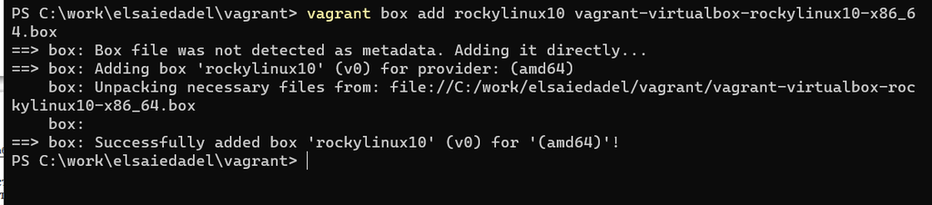

Добавление box-образа

## Файл Vagrantfile

В файле Vagrantfile заданы параметры виртуальных машин: - используемый box-образ; - провайдер VirtualBox; - параметры виртуализации и взаимодействия с хостовой системой.

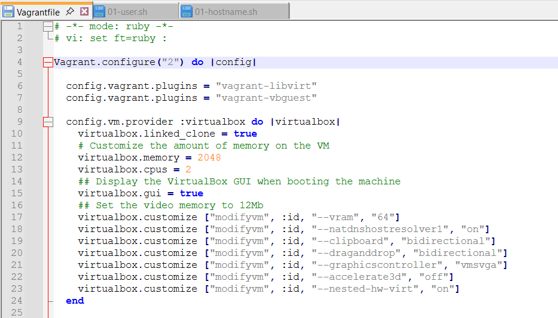

Настройка Vagrantfile

## Создание пользователя

Provisioning-скрипт выполняет автоматическое создание пользователя, назначение пароля, добавление в группу wheel и настройку пользовательского окружения.

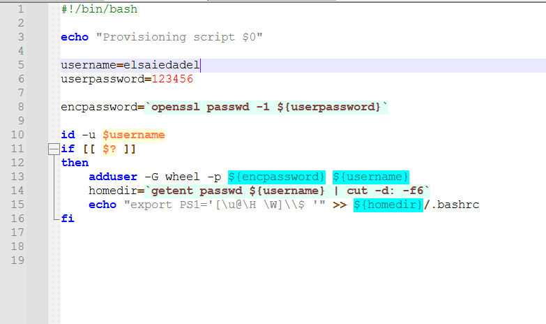

Скрипт создания пользователя

## Настройка имени хоста

Дополнительный provisioning-скрипт задаёт имя хоста виртуальной машины на основе логина пользователя, обеспечивая удобную идентификацию системы в сети.

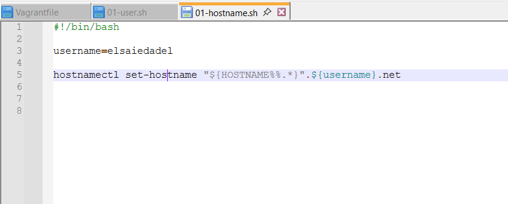

Настройка hostname

## Развёртывание сервера

Виртуальная машина Server была успешно создана и запущена. В процессе выполнено клонирование, настройка сетевых интерфейсов и автоматическая инициализация системы.

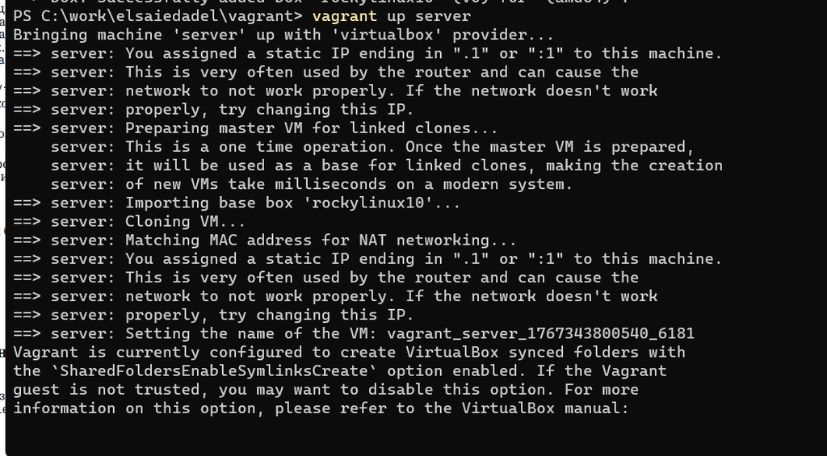

Запуск Server

## Проверка входа в систему

После загрузки системы выполнен вход в графическое окружение под созданным пользователем. Имя хоста соответствует заданной конфигурации.

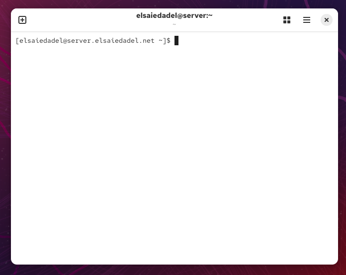

Вход в систему Server

## Работа с сервером

С хостовой системы выполнено подключение к серверу по SSH. Проверена возможность смены пользователя и корректность настройки учётных записей.

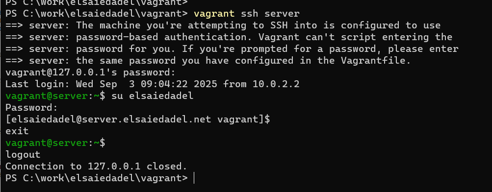

SSH-подключение

## Развёртывание клиента

Аналогичным образом выполнен запуск виртуальной машины Client. Система успешно загружена, сетевые интерфейсы настроены, виртуальная машина готова к работе.

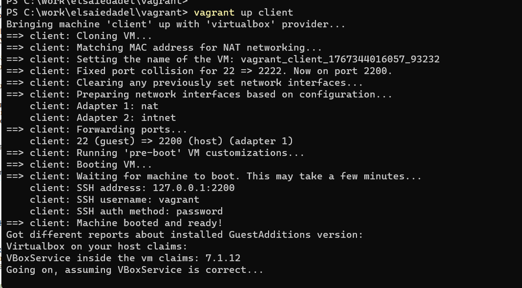

Запуск Client

# Выводы

## Вывод

В ходе лабораторной работы был подготовлен лабораторный стенд на базе VirtualBox с использованием Vagrant. Создан и зарегистрирован box-образ Rocky Linux, выполнена автоматическая настройка виртуальных машин, пользователей и сетевых параметров. Полученные результаты подтверждают корректную работу инструментов автоматизации и возможность их применения для быстрого развёртывания типовых виртуальных сред.